# Coursera Practical Machine Learning: Course Project

Todd Himple

January 27, 2017

## Background

Using devices such as Jawbone Up, Nike FuelBand, and Fitbit it is now possible to collect a large amount of data about personal activity relatively inexpensively. These type of devices are part of the quantified self movement - a group of enthusiasts who take measurements about themselves regularly to improve their health, to find patterns in their behavior, or because they are tech geeks. One thing that people regularly do is quantify how much of a particular activity they do, but they rarely quantify how well they do it.

In this project, my goal is evaulate data from accelerometers on the belt, forearm, arm, and dumbell of 6 participants. They were asked to perform barbell lifts correctly and incorrectly in 5 different ways:

- Class A: exactly according to the specification
- Class B: throwing the elbows to the front
- Class C: lifting the dumbbell only halfway
- Class D: lowering the dumbbell only halfway
- Class E: throwing the hips to the front

More about this study can be found here: http://groupware.les.inf.puc-rio.br/har#literature#ixzz4WEA9mGLy

## R Packages:

Installing possible packages that may be necessary for my analysis

```r
library(caret)
```

```r
library(rpart)
library(rpart.plot)
library(RColorBrewer)
library(rattle)
library(randomForest)
```

## Datasets

Loading datasets and subsetting potentially useful data for analysis

```r
trainUrl <- "http://d396qusza40orc.cloudfront.net/predmachlearn/pml-training.csv"
valUrl <- "http://d396qusza40orc.cloudfront.net/predmachlearn/pml-testing.csv"

Training_Data <- read.csv(url(trainUrl), header=TRUE)
train_subset <- Training_Data[,c(8:11,37:49,60:68,84:86,102,113:124,140,151:160)]

dim(train_subset)
```

```
## [1] 19622    53
```

```r
#[1] 19622    53
#head(train_subset)
```

## Partitioning data

Creating two separate datasets, one for training (75%) and one for testing (25%)

```r
inTrain <- createDataPartition(train_subset$classe, p = .75, list = FALSE)
training_data <- train_subset[inTrain, ]
testing_data <- train_subset[-inTrain, ]

#dim(training_data)
#dim(testing_data)
```

## Model training

```r
set.seed(123) #for reproducability
random_forest <- randomForest(classe~.,data=training_data,ntree=100,importance=TRUE)
random_forest
```

```
##
## Call:
##  randomForest(formula = classe ~ ., data = training_data, ntree = 100,      importance = TRUE)
##                Type of random forest: classification
##                      Number of trees: 100
## No. of variables tried at each split: 7
##
##         OOB estimate of  error rate: 0.56%
## Confusion matrix:
##      A    B    C    D    E  class.error
## A 4182    3    0    0    0 0.0007168459
## B   14 2827    7    0    0 0.0073735955
## C    0    8 2551    8    0 0.0062329568
## D    0    1   31 2378    2 0.0140961857
## E    0    0    1    7 2698 0.0029563932
```

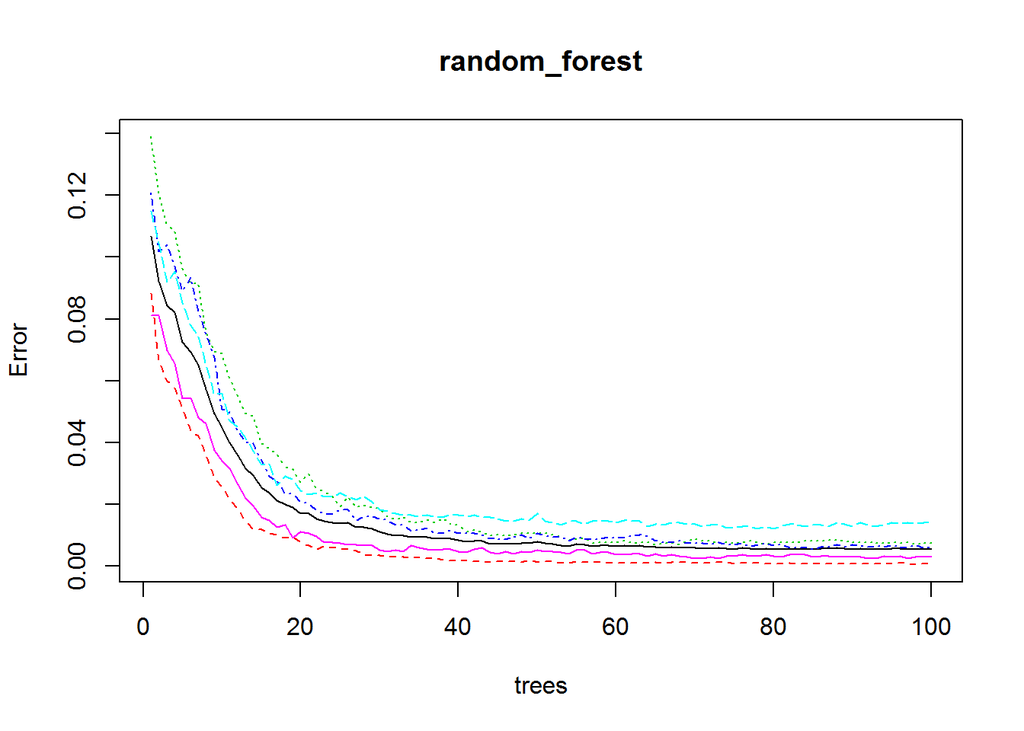

```r
##Plotting the error rate as a function of the number of trees
plot(random_forest)
```

## Validation

```r
test_predictions <- predict(random_forest, newdata=testing_data)
confusionMatrix(test_predictions,testing_data$classe)
```

```
## Confusion Matrix and Statistics
##
##           Reference
## Prediction    A    B    C    D    E
##          A 1395    4    0    0    0
##          B    0  943    3    0    0
##          C    0    2  852    9    0
##          D    0    0    0  795    2
##          E    0    0    0    0  899
##
## Overall Statistics
##
##                Accuracy : 0.9959
##                  95% CI : (0.9937, 0.9975)
##     No Information Rate : 0.2845
##     P-Value [Acc > NIR] : < 2.2e-16
##
##                   Kappa : 0.9948
##  Mcnemar's Test P-Value : NA
##
## Statistics by Class:
##
##                      Class: A Class: B Class: C Class: D Class: E
## Sensitivity            1.0000   0.9937   0.9965   0.9888   0.9978
## Specificity            0.9989   0.9992   0.9973   0.9995   1.0000
## Pos Pred Value         0.9971   0.9968   0.9873   0.9975   1.0000
## Neg Pred Value         1.0000   0.9985   0.9993   0.9978   0.9995
## Prevalence             0.2845   0.1935   0.1743   0.1639   0.1837
## Detection Rate         0.2845   0.1923   0.1737   0.1621   0.1833
## Detection Prevalence   0.2853   0.1929   0.1760   0.1625   0.1833
## Balanced Accuracy      0.9994   0.9965   0.9969   0.9942   0.9989
```

The test dataset was then applied to the trained model, which returned a very high accuracy of 99.59%